# Exploring Fraudulent Transactions

This analysis explores the complex world of fraudulent transactions within a large financial institution. Our dataset contains rows representing credit card transactions, with each transaction labeled as either authentic or fraudulent based on the presence or absence of deceit during the exchange of funds.

### Objective of the Analysis

The primary objective of the analysis is to identify hidden patterns and factors that influence fraudulent transactions. The approach involves exploratory analysis to gain valuable insights into these transactions. The insights generated will then be analyzed through rigorous statistical tests, including T-tests, ANOVA, and regression analysis, to determine their significance and potential impact.

### Analysis Details

1. Exploratory Analysis (EDA): visualization of transaction patterns.
2. T-Test and ANOVA: statistical tests for mean and variance differences.
3. Linear Regression: examining relationships between variables.
4. Conclusion and Recommendations: Summarize findings and suggest further actions.

## Conclusion & Recommendations

**Conclusion**:

- **T-test and Anova Insights:** Significant differences in transaction amounts between fraudulent and non-fraudulent transactions. This suggests that transaction amounts might be a valuable feature to explore further, potentially looking for a specific cutoff amount that could explain fraud patterns.
- **Regression Models:** didn't yield promising results in explaining fraudulent transactions. Indicating the selected independent variables, including transaction amount, credit limit, available money, and current balance, don't adequately explain the variance in fraud.
- **EDA Insights:** The association of fraud with specific transaction types, point-of-sale conditions, and card presence.

**Recommendations:**

- **Geographical Analysis:** Add missing values for merchant location and perform EDA to see if fraud differs across different regions.
- **Merchant Industry Analysis:** Grouping data by industry can help identify specific industries where Fraud is more likely to occur.
- **Feature Engineering:** To improve the performance of our predictive models, is recommended to convert categorical variables into quantitative dummy variables.

## Extract and Process Data

```python
#Importing the necessary packages for use
import json
import pandas as pd
import numpy as np
import os
from scipy import stats
from zipfile import ZipFile
import matplotlib.pyplot as plt
import matplotlib.style as style
import seaborn as sns
```

```python
#Data Extraction:
chunk_size= 10000
chunks= pd.read_json(r"C:\Users\cruzm\OneDrive\Escritorio\COURSES\1. FALL QUARTER\Python\Final Project\transactions.txt",lines=True, chunksize= chunk_size)
df = pd.concat(chunks)
df.head(3)
```

|  | accountNumber | customerId | creditLimit | availableMoney | transactionDateTime | transactionAmount | merchantName | acqCountry | merchantCountryCode | posEntryMode | ... | echoBuffer | currentBalance | merchantCity | merchantState | merchantZip | cardPresent | posOnPremises | recurringAuthInd | expirationDateKeyInMatch | isFraud |
| --- | --- | --- | --- | --- | --- | --- | --- | --- | --- | --- | --- | --- | --- | --- | --- | --- | --- | --- | --- | --- | --- |
| 0 | 737265056 | 737265056 | 5000 | 5000.0 | 2016-08-13T14:27:32 | 98.55 | Uber | US | US | 02 | ... |  | 0.0 |  |  |  | False |  |  | False | False |
| 1 | 737265056 | 737265056 | 5000 | 5000.0 | 2016-10-11T05:05:54 | 74.51 | AMC #191138 | US | US | 09 | ... |  | 0.0 |  |  |  | True |  |  | False | False |
| 2 | 737265056 | 737265056 | 5000 | 5000.0 | 2016-11-08T09:18:39 | 7.47 | Play Store | US | US | 09 | ... |  | 0.0 |  |  |  | False |  |  | False | False |

3 rows × 29 columns

#### **Data Dictionary:**

1. **accountNumber:** The account number associated with the customer.
2. **customerID:** The unique identifier for the customer.
3. **creditLimit:** The maximum amount of credit available to the account.
4. **availableMoney:** The amount of money currently available in the account.
5. **transactionDateTime:** The date and time when the transaction occurred.
6. **transactionAmount:** The amount of money involved in the transaction.
7. **merchantName:** The name of the merchant where the transaction took place.
8. **acqCountry:** The acquiring country code for the transaction.
9. **merchantCountryCode:** The country code of the merchant.
10. **posEntryMode:** The point of sale entry mode code.
11. **posConditionCode:** The point of sale condition code.
12. **merchantCategoryCode:** The category or type of merchant.
13. **currentExpDate:** The current expiration date of the card.
14. **accountOpenDate:** The date when the account was opened.
15. **dateOfLastAddressChange:** The date of the las address change for the account.
16. **cardCVV:** The Card Verification Value on the card.
17. **enteredCVV:** The CVV entered during the transaction.
18. **cardLast4Digits:** The last four digits of the card number.
19. **transactionType:** The type of transaction (e.g., purchase, withdrawal)
20. **echoBuffer:** An unspecified data field.
21. **currentBalance:** The current balance on the account.
22. **merchantCity:** The city where the merchant is located.
23. **merchantState:** The state where the merchant is located.
24. **merchantZip:** The ZIP code of the merchant.
25. **cardPresent:** Indicates whether the card was present during the transaction.
26. **posOnPremises:** Information about the point of sale being on the premises (if applicable).
27. **recurringAuthInd:** Indicates whether the transaction is a recurring authorization.
28. **expirationDateKeyInMatch:** Indicates if the expiration date matches during key entry.
29. **IsFraud:** A binary variable indicating whether the transaction is fraudulent (1 for fraudulent, 0 for non-fraudulent).

```python
#Get a count of missing values
df.replace('', np.nan, inplace=True)
print(df.isnull().sum())
```

```
accountNumber                    0
customerId                       0
creditLimit                      0
availableMoney                   0
transactionDateTime              0
transactionAmount                0
merchantName                     0
acqCountry                    4562
merchantCountryCode            724
posEntryMode                  4054
posConditionCode               409
merchantCategoryCode             0
currentExpDate                   0
accountOpenDate                  0
dateOfLastAddressChange          0
cardCVV                          0
enteredCVV                       0
cardLast4Digits                  0
transactionType                698
echoBuffer                  786363
currentBalance                   0
merchantCity                786363
merchantState               786363
merchantZip                 786363
cardPresent                      0
posOnPremises               786363
recurringAuthInd            786363
expirationDateKeyInMatch         0
isFraud                          0
dtype: int64
```

The dataset contains approximately 786k transactions. As part of the data processing, we need to remove variables with missing values and identify and eliminate duplicates or negative transactions (reverse transactions).

```python
#Drop variables with high missing values
df.drop(['echoBuffer','merchantCity', 'merchantState', 'merchantZip', 'posOnPremises', 'recurringAuthInd',
        'recurringAuthInd'], axis=1, inplace=True)
df = df.reset_index(drop=True)
```

```python
#Impute missing values with the most common category for each column
def impute_missing_with_mode(df, columns):
    for column in columns:
        most_frequent = df[column].mode()[0]
        df[column].fillna(most_frequent, inplace= True)

columns_to_impute= ['acqCountry', 'merchantCountryCode', 'posEntryMode', 'posConditionCode', 'transactionType']
impute_missing_with_mode(df, columns_to_impute)

print(df.isnull().sum())
```

```
accountNumber               0
customerId                  0
creditLimit                 0
availableMoney              0
transactionDateTime         0
transactionAmount           0
merchantName                0
acqCountry                  0
merchantCountryCode         0
posEntryMode                0
posConditionCode            0
merchantCategoryCode        0
currentExpDate              0
accountOpenDate             0
dateOfLastAddressChange     0
cardCVV                     0
enteredCVV                  0
cardLast4Digits             0
transactionType             0
currentBalance              0
cardPresent                 0
expirationDateKeyInMatch    0
isFraud                     0
dtype: int64
```

```python
#Check for negative transactions
negative_transactions = pd.DataFrame(df['transactionAmount'].unique()).sort_values(by=[0])
negative_transactions
```

|  | 0 |
| --- | --- |
| 13 | 0.00 |
| 10256 | 0.01 |
| 7718 | 0.02 |
| 1551 | 0.03 |
| 11409 | 0.04 |
| ... | ... |
| 56746 | 1772.63 |
| 65910 | 1780.60 |
| 63699 | 1873.97 |
| 59098 | 1905.30 |
| 55108 | 2011.54 |

66038 rows × 1 columns

```python
#Total duplicate transactions
set1 = df[["accountNumber", "transactionAmount"]].drop_duplicates()
set2 = df[["accountNumber", "transactionAmount"]]
print('Total Multi-Swipe Transactions:',len(set2)-len(set1))
```

```
Total Multi-Swipe Transactions: 110600
```

There seems to be a high volume of transactions that were swiped more than once. These need to be removed from our dataset to get a true count of deduplicated transactions.

```python
#Drop duplicate transactions based on the 'accountNumber' and 'transactionAmount' columns
df.drop_duplicates(subset= ['accountNumber', 'transactionAmount'], inplace=True)
print('Total Deduplicated Transactions:',len(df))
```

```
Total Deduplicated Transactions: 675763
```

Our dataset is clean and ready to begin the Exploratory Data Analysis and statistical analysis.

## Exploratory Data Analysis

We gained a deeper understanding of the data in this phase by visualizing qualitative and quantitative variables separately, calculating the total transaction count, and examining fraudulent transaction relationships through visualizations.

```python
#Data Structure
df.info()
```

```
<class 'pandas.core.frame.DataFrame'>
Int64Index: 675763 entries, 0 to 786362
Data columns (total 23 columns):
 #   Column                    Non-Null Count   Dtype
---  ------                    --------------   -----
 0   accountNumber             675763 non-null  int64
 1   customerId                675763 non-null  int64
 2   creditLimit               675763 non-null  int64
 3   availableMoney            675763 non-null  float64
 4   transactionDateTime       675763 non-null  object
 5   transactionAmount         675763 non-null  float64
 6   merchantName              675763 non-null  object
 7   acqCountry                675763 non-null  object
 8   merchantCountryCode       675763 non-null  object
 9   posEntryMode              675763 non-null  object
 10  posConditionCode          675763 non-null  object
 11  merchantCategoryCode      675763 non-null  object
 12  currentExpDate            675763 non-null  object
 13  accountOpenDate           675763 non-null  object
 14  dateOfLastAddressChange   675763 non-null  object
 15  cardCVV                   675763 non-null  int64
 16  enteredCVV                675763 non-null  int64
 17  cardLast4Digits           675763 non-null  int64
 18  transactionType           675763 non-null  object
 19  currentBalance            675763 non-null  float64
 20  cardPresent               675763 non-null  bool
 21  expirationDateKeyInMatch  675763 non-null  bool
 22  isFraud                   675763 non-null  bool
dtypes: bool(3), float64(3), int64(6), object(11)
memory usage: 110.2+ MB
```

```python
df.head()
```

|  | accountNumber | customerId | creditLimit | availableMoney | transactionDateTime | transactionAmount | merchantName | acqCountry | merchantCountryCode | posEntryMode | ... | accountOpenDate | dateOfLastAddressChange | cardCVV | enteredCVV | cardLast4Digits | transactionType | currentBalance | cardPresent | expirationDateKeyInMatch | isFraud |
| --- | --- | --- | --- | --- | --- | --- | --- | --- | --- | --- | --- | --- | --- | --- | --- | --- | --- | --- | --- | --- | --- |
| 0 | 737265056 | 737265056 | 5000 | 5000.0 | 2016-08-13T14:27:32 | 98.55 | Uber | US | US | 02 | ... | 2015-03-14 | 2015-03-14 | 414 | 414 | 1803 | PURCHASE | 0.0 | False | False | False |
| 1 | 737265056 | 737265056 | 5000 | 5000.0 | 2016-10-11T05:05:54 | 74.51 | AMC #191138 | US | US | 09 | ... | 2015-03-14 | 2015-03-14 | 486 | 486 | 767 | PURCHASE | 0.0 | True | False | False |
| 2 | 737265056 | 737265056 | 5000 | 5000.0 | 2016-11-08T09:18:39 | 7.47 | Play Store | US | US | 09 | ... | 2015-03-14 | 2015-03-14 | 486 | 486 | 767 | PURCHASE | 0.0 | False | False | False |
| 4 | 830329091 | 830329091 | 5000 | 5000.0 | 2016-03-24T21:04:46 | 71.18 | Tim Hortons #947751 | US | US | 02 | ... | 2015-08-06 | 2015-08-06 | 885 | 885 | 3143 | PURCHASE | 0.0 | True | False | False |
| 5 | 830329091 | 830329091 | 5000 | 5000.0 | 2016-04-19T16:24:27 | 30.76 | In-N-Out #422833 | US | US | 02 | ... | 2015-08-06 | 2015-08-06 | 885 | 885 | 3143 | PURCHASE | 0.0 | True | False | False |

5 rows × 23 columns

```python
#Get list of qualitative/object/text columns
qualcols = df.select_dtypes('object').columns
qualcols
```

```
Index(['transactionDateTime', 'merchantName', 'acqCountry',
       'merchantCountryCode', 'posEntryMode', 'posConditionCode',
       'merchantCategoryCode', 'currentExpDate', 'accountOpenDate',
       'dateOfLastAddressChange', 'transactionType'],
      dtype='object')
```

```python
#Get list of quantitative/int or float columns
quantcol = df.select_dtypes('int64','float64').columns
quantcol
```

```
Index(['accountNumber', 'customerId', 'creditLimit', 'cardCVV', 'enteredCVV',
       'cardLast4Digits'],
      dtype='object')
```

Below are some notable characteristics of our dataset:

- Each row represents a credit card transaction.
- 'isFraud' is our predictor variable, indicating if a transaction was fraudulent or not.
- There are four quantitative variables that will be analyzed for any potential relationship with Fraud: "CreditLimit" "AvailableMoney", "TransactionAmount", "CurrentBalance".
- The qualitative variables that will be analyzed to confirm any visual or statistical significance with fraud, such as the impact on fraud, include transaction date, point of sale (POS), transaction type, and whether the card is present or not.

### Summary Statistics

```python
#Total count of transactions
total_count= df['isFraud'].count()

#Count of fraudulent transactions
fraud_count= df[df['isFraud'] == True]['isFraud'].count()

#Percentage of fraudulent transactions
percentage_fraudulent= fraud_count / total_count
```

```python
#Display summary statistics
print(f"Total Count of Transactions: {total_count}")
print(f"Count of Fraudulent Transactions: {fraud_count}")
print(f"Percent of Fraudulent Transactions: {percentage_fraudulent:.4f}")
```

```
Total Count of Transactions: 675763
Count of Fraudulent Transactions: 11508
Percent of Fraudulent Transactions: 0.0170
```

The % of fraudulent transactions is very small. It would be interesting to see how this number compares to the industry standard for all banks. Let's take a look at the summary statistics by dividing fraudulent and non-fraudulent transactions to see if there are any differences worth noting.

```python
#Summary Statistics for Non-Fraudulent Transactions
print("SUMMARY STATS FOR NON-FRAUDULENT TRANSACTIONS:\n")
df[['creditLimit', 'availableMoney', 'transactionAmount', 'currentBalance']][df.isFraud == False].describe()
```

```
SUMMARY STATS FOR NON-FRAUDULENT TRANSACTIONS:
```

|  | creditLimit | availableMoney | transactionAmount | currentBalance |
| --- | --- | --- | --- | --- |
| count | 664255.000000 | 664255.000000 | 664255.000000 | 664255.000000 |
| mean | 10760.159126 | 6231.585456 | 147.685124 | 4528.573670 |
| std | 11586.125447 | 8872.510478 | 149.701742 | 6395.354322 |
| min | 250.000000 | -1005.630000 | 0.000000 | 0.000000 |
| 25% | 5000.000000 | 1063.550000 | 41.870000 | 707.160000 |
| 50% | 7500.000000 | 3183.910000 | 100.640000 | 2472.740000 |
| 75% | 15000.000000 | 7500.000000 | 204.990000 | 5452.735000 |
| max | 50000.000000 | 50000.000000 | 2011.540000 | 47498.810000 |

```python
#Summary Statistics for Fraudulent Transactions
print("SUMMARY STATS FOR FRAUDULENT TRANSACTIONS:\n")
df[['creditLimit', 'availableMoney', 'transactionAmount', 'currentBalance']][df.isFraud == True].describe()
```

```
SUMMARY STATS FOR FRAUDULENT TRANSACTIONS:
```

|  | creditLimit | availableMoney | transactionAmount | currentBalance |
| --- | --- | --- | --- | --- |
| count | 11508.000000 | 11508.000000 | 11508.000000 | 11508.000000 |
| mean | 11093.196038 | 6228.035680 | 230.188323 | 4865.160358 |
| std | 11999.648478 | 8799.328324 | 190.204612 | 7068.108516 |
| min | 250.000000 | -583.960000 | 0.000000 | 0.000000 |
| 25% | 5000.000000 | 1075.442500 | 90.242500 | 784.710000 |
| 50% | 7500.000000 | 3182.340000 | 182.215000 | 2654.975000 |
| 75% | 15000.000000 | 7684.222500 | 317.875000 | 5661.980000 |
| max | 50000.000000 | 50000.000000 | 1608.350000 | 47473.940000 |

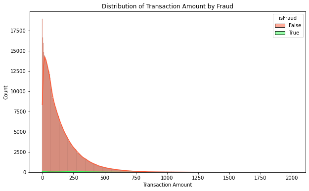

```python
#Histogram of 'transaction Amount' for fraudulent and non-fraudulent transactions
plt.figure(figsize=(10,6))
sns.histplot(data= df, x= 'transactionAmount', hue= 'isFraud', kde= True)
plt.title('Distribution of Transaction Amount by Fraud')
plt.xlabel('Transaction Amount')
plt.show()
```

However, most transactions are classified as non-fraudulent, resulting in a significant class imbalance.

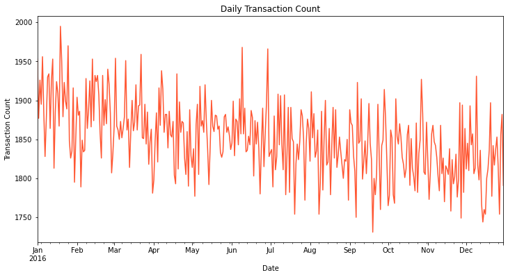

```python
#Time-Series trends in transaction counts by date and time

#Verifying the 'transactionDateTime' column is in datetime format
df['transactionDateTime'] = pd.to_datetime(df['transactionDateTime'])

#Setting 'transactionDateTime' as the DF index
df.set_index('transactionDateTime', inplace= True)

#Daily transactions counts
daily_transactions= df.resample('D').size()

#Viz time-series
plt.figure(figsize=(12,6))
daily_transactions.plot(title= 'Daily Transaction Count')
plt.xlabel('Date')
plt.ylabel('Transaction Count')
plt.show()
```

### Distribution of Quantitative Variables

```python
#Distribution of Wuantitative Variables for Non-Fraudulent Transactions
plt.figure(figsize=(10,6))
style.use('seaborn-poster')
sns.set_style('ticks')
```

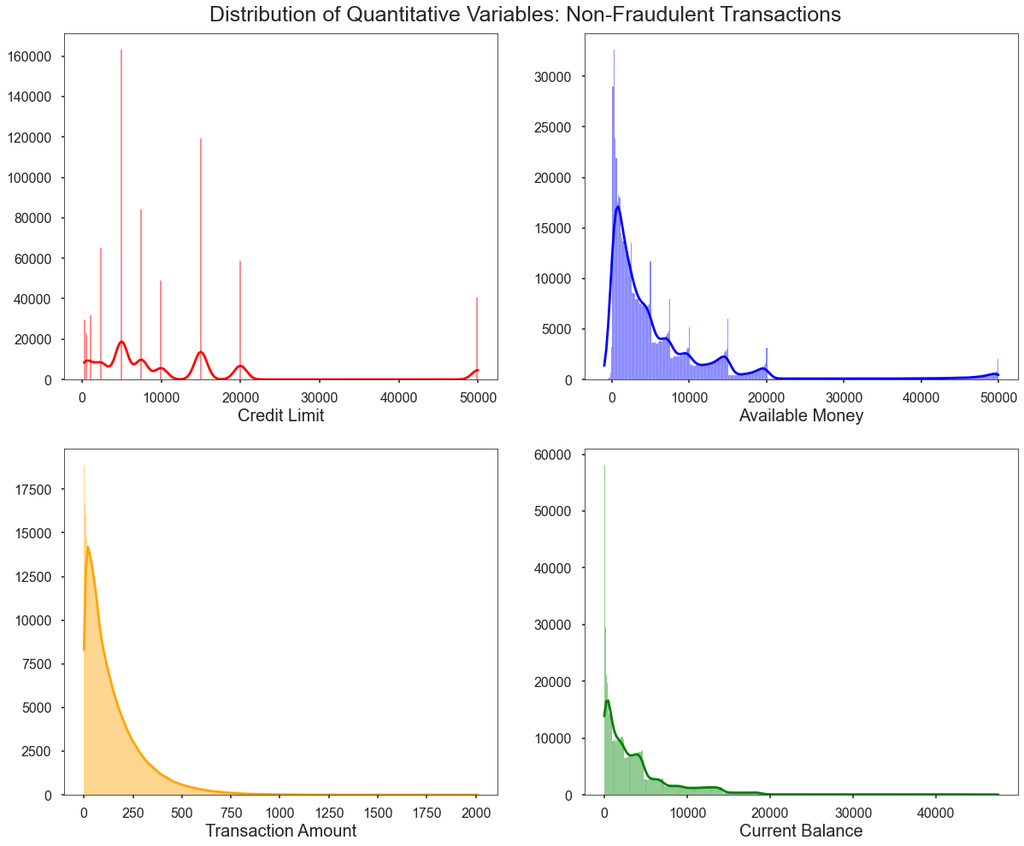

```python
#Variables and labels
fig, ax = plt.subplots(nrows=2, ncols=2, figsize=(20,15))

numeric_cols = ['creditLimit', 'availableMoney', 'transactionAmount', 'currentBalance']
neat_cols = ['Credit Limit', 'Available Money', 'Transaction Amount', 'Current Balance']
colors = ['Red', 'Blue', 'Orange', 'Green']
counter = 0

for i in range(2):
    for j in range(2):
        sns.histplot(df[df['isFraud'] == False].reset_index(drop= True), x= numeric_cols[counter], ax= ax[i][j], color=colors[counter], kde=True)
        ax[i][j].set_xlabel(neat_cols[counter], fontsize=20)
        ax[i][j].set_ylabel('')
        counter+=1

fig.suptitle('Distribution of Quantitative Variables: Non-Fraudulent Transactions', fontsize=25)
fig.subplots_adjust(top=0.95)
```

*Interpretation of distributions:*

**Credit Limit:** Most accounts have credit limits of around 10k. The distribution has several peaks, and there's a distinct group of outliers with a credit limit of 50k.

**Available Money:** The distribution is right-skewed, which is normal because most accounts have credit limits of around 10k, and it's uncommon for customers to max out their credit cards.

**Transaction Amount:** Visually pleasing distribution and slightly right-skewed due to outliers. This is expected because credit card transactions typically involve everyday consumer purchases.

**Current Balance:** Visually pleasing and also slightly right-skewed.

Let's see what each distribution looks like for fraudulent transactions only.

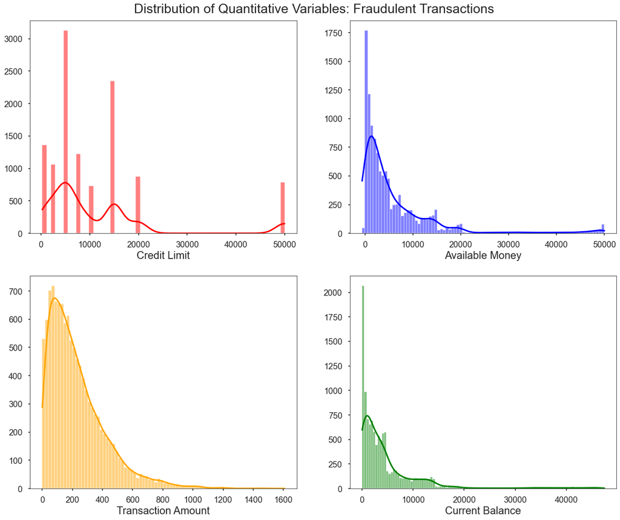

```python
fig, ax = plt.subplots(nrows=2, ncols=2, figsize=(20,15))

numeric_cols = ['creditLimit', 'availableMoney', 'transactionAmount', 'currentBalance']
neat_cols = ['Credit Limit', 'Available Money', 'Transaction Amount', 'Current Balance']
colors = ['Red', 'Blue', 'Orange', 'Green']
counter = 0

for i in range(2):
    for j in range(2):
        sns.histplot(df[df['isFraud'] == True].reset_index(drop= True), x= numeric_cols[counter], ax= ax[i][j], color=colors[counter], kde=True)
        ax[i][j].set_xlabel(neat_cols[counter], fontsize=20)
        ax[i][j].set_ylabel('')
        counter+=1

fig.suptitle('Distribution of Quantitative Variables: Fraudulent Transactions', fontsize=25)
fig.subplots_adjust(top=0.95)

#If 'distplot' does not run, use 'histplot'.
```

### Correlation Matrix

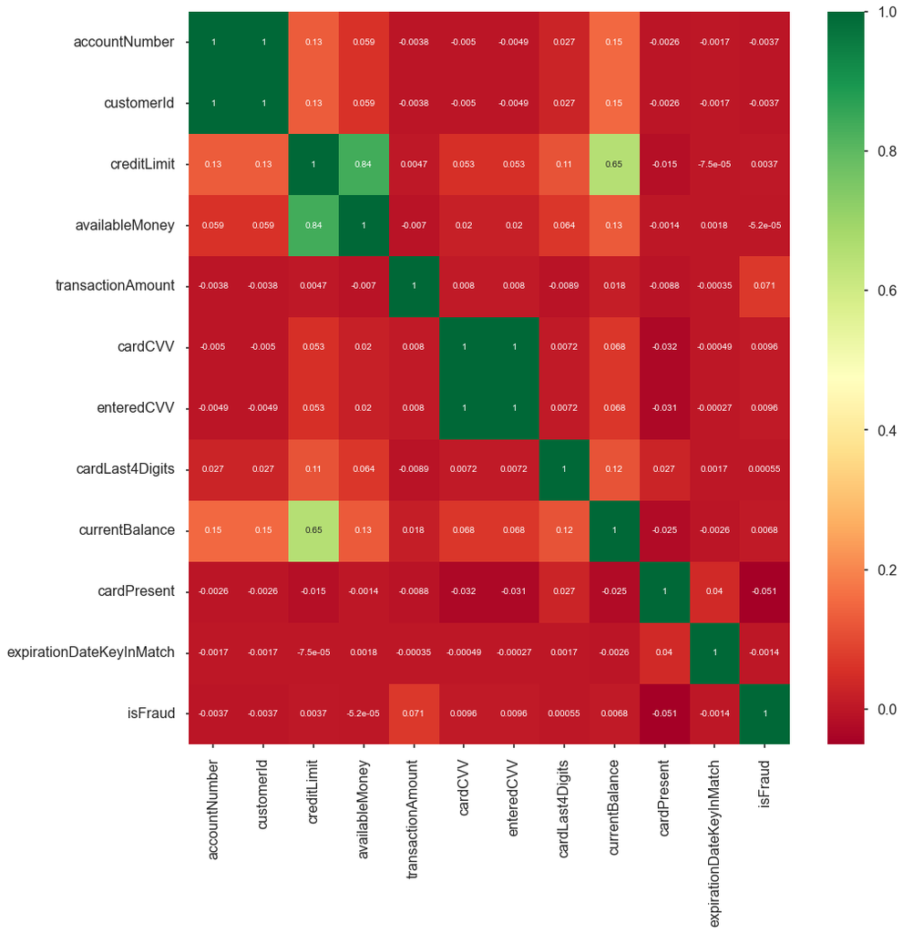

```python
#Correlation of each feature in dataset
corrmatrix = df.corr()
top_corr_features = corrmatrix.index
plt.figure(figsize=(15,15))
#plot heat map
sns.heatmap(df[top_corr_features].corr(),annot=True,cmap="RdYlGn")
```

Strong positive relationship between credit limit and available balance. Additionally, there appears to be a subtle negative relationship between the presence of a card and fraud. We will delve into these relationships to determine whether the association between card presence and fraud holds statistical significance.

### Categorical Comparisons

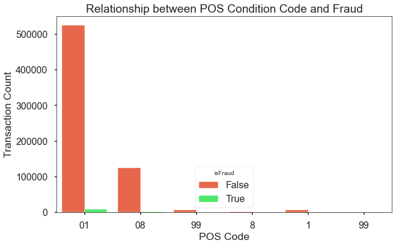

```python
#Defining costume color palette
custom_palette = ['#FF5733', '#33FF57']

#Categorical Comparison: POS Condition Code and Fraud
plt.figure(figsize= (10,6))
sns.set_palette(custom_palette)
sns.countplot(data=df, x='posConditionCode', hue='isFraud')
plt.xlabel('POS Code')
plt.ylabel('Transaction Count')
plt.title('Relationship between POS Condition Code and Fraud')
```

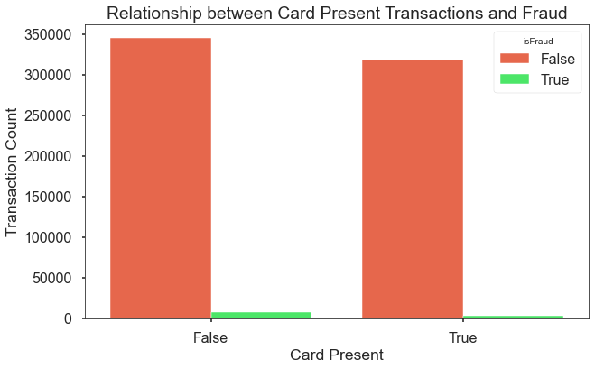

```python
#Categorical Comparison: Card Present and Fraud
plt.figure(figsize=(10,6))
sns.set_palette(custom_palette)
sns.countplot(data=df, x='cardPresent', hue='isFraud')
plt.xlabel('Card Present')
plt.ylabel('Transaction Count')
plt.title('Relationship between Card Present Transactions and Fraud')
```

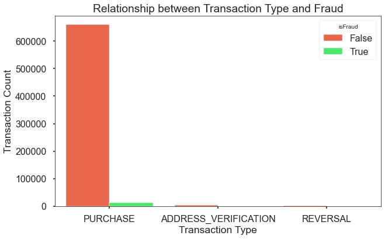

```python
#Categorical Comparison: Transaction Type and Fraud
plt.figure(figsize= (10,6))
sns.set_palette(custom_palette)
sns.countplot(data=df, x='transactionType', hue='isFraud')
plt.xlabel('Transaction Type')
plt.ylabel('Transaction Count')
plt.title('Relationship between Transaction Type and Fraud')
```

The following insights can be derived when visualizing the relationships between POS and Card Present with Fraud:

- Fraudulent transactions occur only for 'purchase' transaction types, which are expected as address verification or reversals are typically security-related.
- Most fraudulent transactions happen when POS is 01, likely indicating physically present transactions. There are also a few fraudulent transactions via mail and phone.
- All fraudulent transactions must match CVV values.
- Most fraudulent transactions occur when the card is not present.
- There is no visual relationship between transaction types and fraud, as all 'purchase' transactions have the same type. The same applies to the country, with most transactions taking place in the US.

## Statistical Analysis

Statistical analyses conducted: T-Test, One-Way ANOVA, and the application of Linear Regression Models.

### T-Test

Perform a test for equal variance and mean of transaction amount between fraudulent and non-fraudulent transactions. Usually, this data point is accessible to the vendors that perform these transactions. Other fields such as available balance might not influence fraud since the vendor does not have access to this data.

```python
#Separate dataset in two: Fraudulent and Non-Fraudulent
df_fraud = df[df['isFraud'] == True]
df_nofraud = df[df['isFraud'] == False]

print("Count of Fraudulent Transactions: ", df_fraud.isFraud.count())
print("Count og Non-Fraudulent Transactions: ", df_nofraud.isFraud.count())
```

```
Count of Fraudulent Transactions:  11508
Count og Non-Fraudulent Transactions:  664255
```

```python
#Calculate the p value and test statistic
stats.bartlett(df_nofraud['transactionAmount'],df_fraud['transactionAmount'])
```

```
BartlettResult(statistic=1521.3374440543614, pvalue=0.0)
```

```python
tvar, p_valvar = stats.bartlett(df_nofraud['transactionAmount'],df_fraud['transactionAmount'])
tvar
```

```
1521.3374440543614
```

```python
#T-Test for equal variances
alpha = .05

if p_valvar < alpha:
    tEqVar=False
    ttype='Welch (unequal variances) Two-Sample t test'
    print("Test of Equal Variances: Reject Ho - The variances are not equal")
else:
    tEqVar=True
    ttype='Two-Sample t test (assuming equal variances)'
    print("Test of Equal Variances: Fail to Reject Ho - The variances are the same")
```

```
Test of Equal Variances: Reject Ho - The variances are not equal
```

```python
#T-Test for equal means
tmean, p_valmean = stats.ttest_ind(df_nofraud['transactionAmount'],df_fraud['transactionAmount'],equal_var=tEqVar)

alpha= 0.05

print("This is a " + ttype + " of equal means with Ho: The group means are equal")
print(f"The t test statistic is {round(tmean,3)} and the p-value is {round(p_valmean,4)}")

if p_valmean < alpha:
    print("Conclusion: Reject Ho - The means are not equal")
else:
    print("Conclusion: Fail to Reject Ho - The means are the same")
```

```
This is a Welch (unequal variances) Two-Sample t test of equal means with Ho: The group means are equal
The t test statistic is -46.284 and the p-value is 0.0
Conclusion: Reject Ho - The means are not equal
```

**T-test interpretation:** there is a statistical difference between the variance and the mean of transaction amounts when comparing fraudulent and non-fraudulent transactions. The means and variance of transaction amount differ between the fraudulent and non-fraudulent groups.

### One-Way ANOVA

Perform a test to confirm if there is equal variance and mean of transaction amount for fraudulent transactions only within each point of sale (POS).

```python
#Separate the dataset for Fraudulent transactions by POS condition code
df_fraud_01 = df_fraud[df_fraud['posConditionCode'] == '01']
df_fraud_08 = df_fraud[df_fraud['posConditionCode'] == '08']
df_fraud_99 = df_fraud[df_fraud['posConditionCode'] == '99']

print("Count of POS 01 Fraudulent Transactions: ", df_fraud_01.isFraud.count())
print("Count of POS 08 Fraudulent Transactions: ", df_fraud_08.isFraud.count())
print("Count of POS 99 Fraudulent Transactions: ", df_fraud_99.isFraud.count())
```

```
Count of POS 01 Fraudulent Transactions:  9413
Count of POS 08 Fraudulent Transactions:  1774
Count of POS 99 Fraudulent Transactions:  211
```

```python
#Calculate F-statistic and p-value
stats.f_oneway(df_fraud_01['transactionAmount'], df_fraud_08['transactionAmount'],
               df_fraud_99['transactionAmount'])
```

```
F_onewayResult(statistic=0.1847873093504683, pvalue=0.8312835420015727)
```

```python
#One-Way ANOVA test
f, p_val = stats.f_oneway(df_fraud_01['transactionAmount'], df_fraud_08['transactionAmount'],
               df_fraud_99['transactionAmount'])
alpha= 0.05

print("This is a test of equal means with Ho: The means of all groups are equal/ Ha: At least one group mean is different")
print(f"The F-test statistic is {round(f,3)} and the p-value is {round(p_val,4)}")

if p_val < alpha:
    print("Conclusion: Reject Ho - At least one group mean is different")
    ANOVAtype = "ANOVA: At least one group mean is different"
else:
    print("Conclusion: Fail to Reject Ho - We can't reject that the means are the same")
    ANOVAtype = "ANOVA: Group Means are the same"
```

[output not shown]

### Linear Regression

Perform a linear regression model between our quantitative variables to confirm if there is a statistical significance that could explain the variance of fraud across all transactions.

- Model 1: Fraud and Transaction Amount
- Model 2: Fraud and Transaction Amount + Credit Limit + Available Money + Current Balance.

```python
#Convert dependent variale (isFraud) to numeric
df["isFraud_Numeric"] = np.where(df['isFraud'] == True, 1, 0)
df.head()
```

| transactionDateTime | accountNumber | customerId | creditLimit | availableMoney | transactionAmount | merchantName | acqCountry | merchantCountryCode | posEntryMode | posConditionCode | ... | dateOfLastAddressChange | cardCVV | enteredCVV | cardLast4Digits | transactionType | currentBalance | cardPresent | expirationDateKeyInMatch | isFraud | isFraud_Numeric |
| --- | --- | --- | --- | --- | --- | --- | --- | --- | --- | --- | --- | --- | --- | --- | --- | --- | --- | --- | --- | --- | --- |
| 2016-08-13 14:27:32 | 737265056 | 737265056 | 5000 | 5000.0 | 98.55 | Uber | US | US | 02 | 01 | ... | 2015-03-14 | 414 | 414 | 1803 | PURCHASE | 0.0 | False | False | False | 0 |
| 2016-10-11 05:05:54 | 737265056 | 737265056 | 5000 | 5000.0 | 74.51 | AMC #191138 | US | US | 09 | 01 | ... | 2015-03-14 | 486 | 486 | 767 | PURCHASE | 0.0 | True | False | False | 0 |
| 2016-11-08 09:18:39 | 737265056 | 737265056 | 5000 | 5000.0 | 7.47 | Play Store | US | US | 09 | 01 | ... | 2015-03-14 | 486 | 486 | 767 | PURCHASE | 0.0 | False | False | False | 0 |
| 2016-03-24 21:04:46 | 830329091 | 830329091 | 5000 | 5000.0 | 71.18 | Tim Hortons #947751 | US | US | 02 | 01 | ... | 2015-08-06 | 885 | 885 | 3143 | PURCHASE | 0.0 | True | False | False | 0 |
| 2016-04-19 16:24:27 | 830329091 | 830329091 | 5000 | 5000.0 | 30.76 | In-N-Out #422833 | US | US | 02 | 01 | ... | 2015-08-06 | 885 | 885 | 3143 | PURCHASE | 0.0 | True | False | False | 0 |

5 rows × 23 columns

```python
#Run linear regression model 1: Fraud and Transaction Amount
from statsmodels.formula.api import ols

#df[['creditLimit', 'availableMoney', 'transactionAmount', 'currentBalance']][df.isFraud == False].describe()

model1 = ols("isFraud_Numeric ~ transactionAmount", data=df).fit()
print(model1.summary()) # Print the results
```

```
                            OLS Regression Results
==============================================================================
Dep. Variable:        isFraud_Numeric   R-squared:                       0.005
Model:                            OLS   Adj. R-squared:                  0.005
Method:                 Least Squares   F-statistic:                     3400.
Date:                Fri, 13 Oct 2023   Prob (F-statistic):               0.00
Time:                        18:05:13   Log-Likelihood:             4.2476e+05
No. Observations:              675763   AIC:                        -8.495e+05
Df Residuals:                  675761   BIC:                        -8.495e+05
Df Model:                           1
Covariance Type:            nonrobust
=====================================================================================
                        coef    std err          t      P>|t|      [0.025      0.975]
-------------------------------------------------------------------------------------
Intercept             0.0080      0.000     36.165      0.000       0.008       0.008
transactionAmount  6.068e-05   1.04e-06     58.312      0.000    5.86e-05    6.27e-05
==============================================================================
Omnibus:                   859257.118   Durbin-Watson:                   1.953
Prob(Omnibus):                  0.000   Jarque-Bera (JB):         85932664.569
Skew:                           7.410   Prob(JB):                         0.00
Kurtosis:                      56.219   Cond. No.                         298.
==============================================================================

Notes:
[1] Standard Errors assume that the covariance matrix of the errors is correctly specified.
```

```python
#Run linear regression model 2: Fraud and Transaction Amount
from statsmodels.formula.api import ols

#df[['creditLimit', 'availableMoney', 'transactionAmount', 'currentBalance']][df.isFraud == False].describe()

model2 = ols("isFraud_Numeric ~ transactionAmount + creditLimit + availableMoney + currentBalance", data=df).fit()
print(model2.summary()) # Print the results
```

```
                            OLS Regression Results
==============================================================================
Dep. Variable:        isFraud_Numeric   R-squared:                       0.005
Model:                            OLS   Adj. R-squared:                  0.005
Method:                 Least Squares   F-statistic:                     1140.
Date:                Fri, 13 Oct 2023   Prob (F-statistic):               0.00
Time:                        18:05:17   Log-Likelihood:             4.2477e+05
No. Observations:              675763   AIC:                        -8.495e+05
Df Residuals:                  675759   BIC:                        -8.495e+05
Df Model:                           3
Covariance Type:            nonrobust
=====================================================================================
                        coef    std err          t      P>|t|      [0.025      0.975]
-------------------------------------------------------------------------------------
Intercept             0.0075      0.000     28.375      0.000       0.007       0.008
transactionAmount  6.059e-05   1.04e-06     58.216      0.000    5.86e-05    6.26e-05
creditLimit        3.603e-08   9.52e-09      3.785      0.000    1.74e-08    5.47e-08
availableMoney    -4.002e-08   1.53e-08     -2.613      0.009      -7e-08      -1e-08
currentBalance     7.605e-08   1.82e-08      4.173      0.000    4.03e-08    1.12e-07
==============================================================================
Omnibus:                   859232.602   Durbin-Watson:                   1.953
Prob(Omnibus):                  0.000   Jarque-Bera (JB):         85921743.981
Skew:                           7.410   Prob(JB):                         0.00
Kurtosis:                      56.216   Cond. No.                     2.16e+15
==============================================================================

Notes:
[1] Standard Errors assume that the covariance matrix of the errors is correctly specified.
[2] The smallest eigenvalue is 5.55e-17. This might indicate that there are
strong multicollinearity problems or that the design matrix is singular.
```